# Human Activity Recognition Analysis

Raghurama Bhat

April 25, 2015

## Introduction

The goal of this document is to analyze the accelerometer data from several users performing wight lifting exercises and fit a machine learning model to the data that allows us to predict the activity they are performing by looking at the sensor data. The data for this project come from this source: http://groupware.les.inf.puc-rio.br/har.

## Pre-processing

The training data for this project are available here:

https://d396qusza40orc.cloudfront.net/predmachlearn/pml-training.csv

The test data are available here:

https://d396qusza40orc.cloudfront.net/predmachlearn/pml-testing.csv.

cursory inspection of the dataset reveals that there are many columns with NA values, Div/0 errors and blank values. We will drop all these columns and leave only the accelerometer data.

```r
#download the data files if it does not exist
if (!file.exists("pml-training.csv") | !file.exists("pml-testing.csv")) {
        download.file("https://d396qusza40orc.cloudfront.net/predmachlearn/pml-training.csv","pml_training.csv","curl",quiet=TRUE)
        download.file("https://d396qusza40orc.cloudfront.net/predmachlearn/pml-testing.csv","pml-testing.csv","curl",quiet=TRUE)
}

#Load the Training and Test Data
train_data <- read.csv("pml-training.csv")
test_data <- read.csv("pml-testing.csv")
# First draw all the columns with NA values
train_data <- train_data[,colSums(is.na(train_data)) ==0]
test_data <- test_data[,colSums(is.na(test_data)) ==0]
# Now select only the Accelerator data columns with valid data
train_data <- subset(train_data, select=c(roll_belt:total_accel_belt,gyros_belt_x:magnet_arm_z,roll_dumbbell:yaw_dumbbell,total_accel_dumbbell:yaw_forearm,total_accel_forearm:classe))
test_data <- subset(test_data, select=c(roll_belt:total_accel_belt,gyros_belt_x:magnet_arm_z,roll_dumbbell:yaw_dumbbell,total_accel_dumbbell:yaw_forearm,total_accel_forearm:problem_id))
```

## Model selection

Since we have to do multiple class prediction our choices here are K Nearest Neighbor, Random Forest. We will try these two model fits and consider additional ones if necessary

Since there is large amount of data, we need to enable the parallel processing using the doParallel package

```r
library(doParallel)
library(caret)
set.seed(400)

#Enable parallel processing
cl <- makeCluster(4)
registerDoParallel(cl)

#Split the training data into two partitions for training and validation
splits <- createDataPartition(train_data$classe,2,0.8,FALSE)
train_split <- train_data[splits,]
test_split <- train_data[-splits,]
```

### K Nearest Neighbor Model

Build a K Nearest Neighbor model using the caret package. knn algorithm requires the data to be normalized. Therefore, add the center and scale pre-proecessing to the train command.

```r
ctrl <- trainControl(method="repeatedcv",repeats = 3)

knnFit <- train(classe ~ ., data = train_split, method = "knn", trControl = ctrl, preProcess = c("center","scale"))
```

Print the Model Object.

```r
knnFit
```

```
## k-Nearest Neighbors
##
## 31398 samples
##    52 predictor
##     5 classes: 'A', 'B', 'C', 'D', 'E'
##
## Pre-processing: centered, scaled
## Resampling: Cross-Validated (10 fold, repeated 3 times)
##
## Summary of sample sizes: 28257, 28258, 28258, 28257, 28258, 28257, ...
##
## Resampling results across tuning parameters:
##
##   k  Accuracy   Kappa      Accuracy SD  Kappa SD
##   5  0.9898297  0.9871356  0.001963997  0.002483998
##   7  0.9827059  0.9781225  0.001950922  0.002468371
##   9  0.9787249  0.9730844  0.002264017  0.002864469
##
## Accuracy was used to select the optimal model using  the largest value.
## The final value used for the model was k = 5.
```

Plot the Model Object

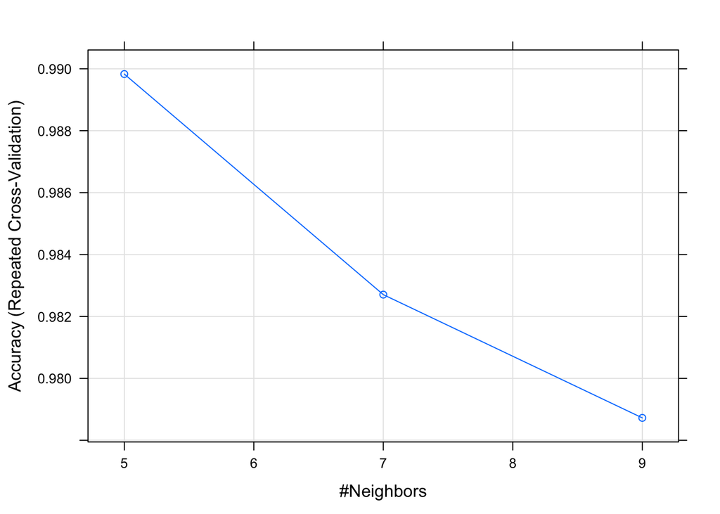

```r
plot(knnFit)
```

Using the model, we can now predict the classes for the test data and compute the out of sample error by generating the confusion matrix. Overall accuracy is We get the overall Accuracy of the model to be 98.58%. Therefore we can estimate the Out of Sample Error rate to be 1- Accuracy which is 1.42%.

```r
knnPredict <- predict(knnFit,newdata = test_split )
confusionMatrix(knnPredict, test_split$classe)
```

```
## Confusion Matrix and Statistics
##
##           Reference
## Prediction   A   B   C   D   E
##          A 246   1   1   0   0
##          B   1 122   1   0   0
##          C   0   3 133   4   0
##          D   0   0   0 114   0
##          E   0   0   0   0 148
##
## Overall Statistics
##
##                Accuracy : 0.9858
##                  95% CI : (0.9747, 0.9929)
##     No Information Rate : 0.3191
##     P-Value [Acc > NIR] : < 2.2e-16
##
##                   Kappa : 0.9818
##  Mcnemar's Test P-Value : NA
##
## Statistics by Class:
##
##                      Class: A Class: B Class: C Class: D Class: E
## Sensitivity            0.9960   0.9683   0.9852   0.9661   1.0000
## Specificity            0.9962   0.9969   0.9890   1.0000   1.0000
## Pos Pred Value         0.9919   0.9839   0.9500   1.0000   1.0000
## Neg Pred Value         0.9981   0.9938   0.9968   0.9939   1.0000
## Prevalence             0.3191   0.1628   0.1744   0.1525   0.1912
## Detection Rate         0.3178   0.1576   0.1718   0.1473   0.1912
## Detection Prevalence   0.3204   0.1602   0.1809   0.1473   0.1912
## Balanced Accuracy      0.9961   0.9826   0.9871   0.9831   1.0000
```

### Random Forest Fit Model

Build a Random Forest model using the caret package.

```r
rfFit <- train(classe ~ ., data = train_split, method = "rf")
```

Print the Model Object.

```r
rfFit
```

```
## Random Forest
##
## 31398 samples
##    52 predictor
##     5 classes: 'A', 'B', 'C', 'D', 'E'
##
## No pre-processing
## Resampling: Bootstrapped (25 reps)
##
## Summary of sample sizes: 31398, 31398, 31398, 31398, 31398, 31398, ...
##
## Resampling results across tuning parameters:
##
##   mtry  Accuracy   Kappa      Accuracy SD   Kappa SD
##    2    0.9974621  0.9967883  0.0007623328  0.0009649294
##   27    0.9971501  0.9963935  0.0007053235  0.0008929290
##   52    0.9934047  0.9916543  0.0016151394  0.0020412003
##
## Accuracy was used to select the optimal model using  the largest value.
## The final value used for the model was mtry = 2.
```

Plot the Model Object

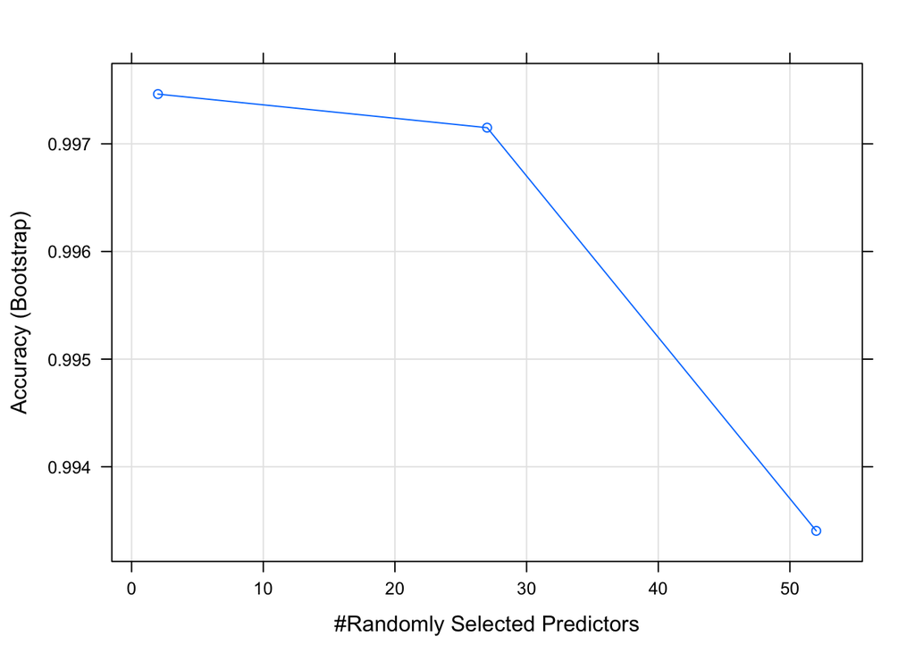

```r
plot(rfFit)
```

Using the model, we can now predict the classes for the test data and compute the out of sample error by generating the confusion matrix. Overall accuracy is We get the overall Accuracy of the model to be 99.87%. Therefore we can estimate the Out of Sample Error rate to be 1- Accuracy which is 0.13%.

```r
rfPredict <- predict(rfFit,newdata = test_split )
confusionMatrix(rfPredict, test_split$classe )
```

```
## Confusion Matrix and Statistics
##
##           Reference
## Prediction   A   B   C   D   E
##          A 247   0   0   0   0
##          B   0 126   0   0   0
##          C   0   0 135   1   0
##          D   0   0   0 117   0
##          E   0   0   0   0 148
##
## Overall Statistics
##
##                Accuracy : 0.9987
##                  95% CI : (0.9928, 1)
##     No Information Rate : 0.3191
##     P-Value [Acc > NIR] : < 2.2e-16
##
##                   Kappa : 0.9983
##  Mcnemar's Test P-Value : NA
##
## Statistics by Class:
##
##                      Class: A Class: B Class: C Class: D Class: E
## Sensitivity            1.0000   1.0000   1.0000   0.9915   1.0000
## Specificity            1.0000   1.0000   0.9984   1.0000   1.0000
## Pos Pred Value         1.0000   1.0000   0.9926   1.0000   1.0000
## Neg Pred Value         1.0000   1.0000   1.0000   0.9985   1.0000
## Prevalence             0.3191   0.1628   0.1744   0.1525   0.1912
## Detection Rate         0.3191   0.1628   0.1744   0.1512   0.1912
## Detection Prevalence   0.3191   0.1628   0.1757   0.1512   0.1912
## Balanced Accuracy      1.0000   1.0000   0.9992   0.9958   1.0000
```

### Conclusion.

In this analysis, Both the K-Nearest Neighbor and Random Forest model have generated very good results and low estimated out of sample error rates. We will use the Random Forest model since it has the higher overall accuracy and lowest estimated out of sample error rate

We can compute our final predictions using the Random Forest Model.

```r
rfTest <- predict(rfFit,newdata = test_data )
```